# Vidensdatabase

Her finder du BUVM’s vidensdatabase over ‘hvad der virker’ for forskellige indsatsområder.

Hvert indsatsområde har sin egen fane nedenfor. Der er aktuelt 6 indsatser.

For hver indsats findes en tabel som viser effekten (‘effect size’) for indsatsen på en given målgruppe. Man kan søge direkte i tabellen, men kan kan også benytte de to knapper “Filtrer rækker” og “Vælg kolonner”.

- *Filtrer rækker* gør det muligt hurtigt at søge på flere parametre. Fx hvis man kun vil se danske resultater som er signifikanter.
- *Vælg kolonner* gør det muligt at tilføje detaljer, fx noter til studiet, som forfattet af BUVM, samt den fulde reference til studiets publicering. I nogle tilfælde linkes der direkte til artiklen. Dette link kan også findes her.

# Studier

Nedenfor kan findes en række effekter fra studier af forskellige indsatser.

Figren nedenfor viser, hvordan hver indsats kan have en effekt på et mål (outcome). Ofte vil målet være et såkaldt link-outcome som kan bruges til at udregne den indirekte som indsatsen har på en andet mål.

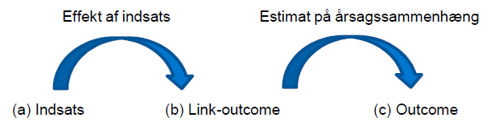

## Uddannet personale

| Indsatsbeskrivelse | Målgruppebeskrivelse | Mål | Effect size (hvis mulig) | Signifikant | Kvalitet | Land | Noter | link | Fuld reference |
| --- | --- | --- | --- | --- | --- | --- | --- | --- | --- |
| Undervisning af nyuddannet lærer | Elever i 3. klasse | Test score læsning | 0.048 | Nej | Statistisk kontrolgruppe | Frankrig |  | Intet link | Bressoux P, Kramarz F, Prost C. Teachers' training, class size and students' outcomes: Learning from administrative forecasting mistakes. The economic journal; 199: 540-561 |
| Undervisning af nyuddannet lærer | Elever i 3. klasse low achieving | Test score læsning | 0.053 | Nej | Statistisk kontrolgruppe | Frankrig |  | Intet link | Bressoux P, Kramarz F, Prost C. Teachers' training, class size and students' outcomes: Learning from administrative forecasting mistakes. The economic journal; 199: 540-561 |
| Undervisning af nyuddannet lærer | Elever i 3. klasse medium low-achieving | Test score læsning | 0.023 | Nej | Statistisk kontrolgruppe | Frankrig |  | Intet link | Bressoux P, Kramarz F, Prost C. Teachers' training, class size and students' outcomes: Learning from administrative forecasting mistakes. The economic journal; 199: 540-561 |
| Undervisning af nyuddannet lærer | Elever i 3. klasse medium high-achieving | Test score læsning | 0.022 | Nej | Statistisk kontrolgruppe | Frankrig |  | Intet link | Bressoux P, Kramarz F, Prost C. Teachers' training, class size and students' outcomes: Learning from administrative forecasting mistakes. The economic journal; 199: 540-561 |
| Undervisning af nyuddannet lærer | Elever i 3. klasse high-achieving | Test score læsning | 0.098 | Nej | Statistisk kontrolgruppe | Frankrig |  | Intet link | Bressoux P, Kramarz F, Prost C. Teachers' training, class size and students' outcomes: Learning from administrative forecasting mistakes. The economic journal; 199: 540-561 |
| Undervisning af nyuddannet lærer | Elever i 3. klasse | Test score matematik | 0.241 | Ja | Statistisk kontrolgruppe | Frankrig |  | Intet link | Bressoux P, Kramarz F, Prost C. Teachers' training, class size and students' outcomes: Learning from administrative forecasting mistakes. The economic journal; 199: 540-561 |
| Undervisning af nyuddannet lærer | Elever i 3. klasse low achieving | Test score matematik | 0.119 | Nej | Statistisk kontrolgruppe | Frankrig |  | Intet link | Bressoux P, Kramarz F, Prost C. Teachers' training, class size and students' outcomes: Learning from administrative forecasting mistakes. The economic journal; 199: 540-561 |
| Undervisning af nyuddannet lærer | Elever i 3. klasse medium low-achieving | Test score matematik | 0.269 | Ja | Statistisk kontrolgruppe | Frankrig |  | Intet link | Bressoux P, Kramarz F, Prost C. Teachers' training, class size and students' outcomes: Learning from administrative forecasting mistakes. The economic journal; 199: 540-561 |
| Undervisning af nyuddannet lærer | Elever i 3. klasse medium high-achieving | Test score matematik | 0.271 | Ja | Statistisk kontrolgruppe | Frankrig |  | Intet link | Bressoux P, Kramarz F, Prost C. Teachers' training, class size and students' outcomes: Learning from administrative forecasting mistakes. The economic journal; 199: 540-561 |
| Undervisning af nyuddannet lærer | Elever i 3. klasse high-achieving | Test score matematik | 0.334 | Ja | Statistisk kontrolgruppe | Frankrig |  | Intet link | Bressoux P, Kramarz F, Prost C. Teachers' training, class size and students' outcomes: Learning from administrative forecasting mistakes. The economic journal; 199: 540-561 |

[output cut: 845 more lines]

## Ordblinde

| Indsatsbeskrivelse | Målgruppebeskrivelse | Mål | Effect size (hvis mulig) | Signifikant | Kvalitet | Land | Noter | link | Fuld reference |
| --- | --- | --- | --- | --- | --- | --- | --- | --- | --- |
| RCT, staveindsatser | Børn, unge eller voksne med dysleksi eller stavevanskeligheder | Effect size (Hedges’ g) | 0.58 | Ja | Lodtrækningsforsøg eller metaanalyse | 6 lande |  | Intet link | Galuschka, K., Görgen, R., Kalmar, J., Haberstroh, S., Schmalz, X., & Schulte-Körne, G. (2020). Effectiveness of spelling interventions for learners with dyslexia: A meta-analysis and systematic revie… |
| RCT, staveindsatser | Børn, unge eller voksne med dysleksi eller stavevanskeligheder | Effect size (Hedges’ g) | 0.68 | Ja | Lodtrækningsforsøg eller metaanalyse | 6 lande |  | Intet link | Galuschka, K., Görgen, R., Kalmar, J., Haberstroh, S., Schmalz, X., & Schulte-Körne, G. (2020). Effectiveness of spelling interventions for learners with dyslexia: A meta-analysis and systematic revie… |
| RCT,, staveindsatser | Børn, unge eller voksne med dysleksi eller stavevanskeligheder | Effect size (Hedges’ g) | 0.42 | Ja | Lodtrækningsforsøg eller metaanalyse | Ukendt |  | Intet link | Galuschka, K., Görgen, R., Kalmar, J., Haberstroh, S., Schmalz, X., & Schulte-Körne, G. (2020). Effectiveness of spelling interventions for learners with dyslexia: A meta-analysis and systematic revie… |
| RCT,, fonem-grafem-træning | Børn, unge eller voksne med dysleksi eller stavevanskeligheder | Effect size (Hedges’ g) | 0.68 | Ja | Lodtrækningsforsøg eller metaanalyse | Ukendt |  | Intet link | Galuschka, K., Görgen, R., Kalmar, J., Haberstroh, S., Schmalz, X., & Schulte-Körne, G. (2020). Effectiveness of spelling interventions for learners with dyslexia: A meta-analysis and systematic revie… |
| RCT,, fonem-grafem-træning | Børn, unge eller voksne med dysleksi eller stavevanskeligheder | Effect size (Hedges’ g) | 0.62 | Ja | Lodtrækningsforsøg eller metaanalyse | Ukendt |  | Intet link | Galuschka, K., Görgen, R., Kalmar, J., Haberstroh, S., Schmalz, X., & Schulte-Körne, G. (2020). Effectiveness of spelling interventions for learners with dyslexia: A meta-analysis and systematic revie… |
| RCT,g, morfologisk opmærksomhed | Børn, unge eller voksne med dysleksi eller stavevanskeligheder | Effect size (Hedges’ g) | 0.8 | Ja | Lodtrækningsforsøg eller metaanalyse | Ukendt |  | Intet link | Galuschka, K., Görgen, R., Kalmar, J., Haberstroh, S., Schmalz, X., & Schulte-Körne, G. (2020). Effectiveness of spelling interventions for learners with dyslexia: A meta-analysis and systematic revie… |
| RCT, morfologisk opmærksomhed | Børn, unge eller voksne med dysleksi eller stavevanskeligheder | Effect size (Hedges’ g) | 0.3 | Nej | Lodtrækningsforsøg eller metaanalyse | Ukendt |  | Intet link | Galuschka, K., Görgen, R., Kalmar, J., Haberstroh, S., Schmalz, X., & Schulte-Körne, G. (2020). Effectiveness of spelling interventions for learners with dyslexia: A meta-analysis and systematic revie… |
| RCT, ortografisk viden | Børn, unge eller voksne med dysleksi eller stavevanskeligheder | Effect size (Hedges’ g) | 0.67 | Ja | Lodtrækningsforsøg eller metaanalyse | Ukendt |  | Intet link | Galuschka, K., Görgen, R., Kalmar, J., Haberstroh, S., Schmalz, X., & Schulte-Körne, G. (2020). Effectiveness of spelling interventions for learners with dyslexia: A meta-analysis and systematic revie… |
| RCT, ortografisk viden | Børn, unge eller voksne med dysleksi eller stavevanskeligheder | Effect size (Hedges’ g) | 0.19 | Ja | Lodtrækningsforsøg eller metaanalyse | Ukendt |  | Intet link | Galuschka, K., Görgen, R., Kalmar, J., Haberstroh, S., Schmalz, X., & Schulte-Körne, G. (2020). Effectiveness of spelling interventions for learners with dyslexia: A meta-analysis and systematic revie… |
| RCT,, ordhukommelse | Børn, unge eller voksne med dysleksi eller stavevanskeligheder | Effect size (Hedges’ g) | 0.22 | Nej | Lodtrækningsforsøg eller metaanalyse | Ukendt |  | Intet link | Galuschka, K., Görgen, R., Kalmar, J., Haberstroh, S., Schmalz, X., & Schulte-Körne, G. (2020). Effectiveness of spelling interventions for learners with dyslexia: A meta-analysis and systematic revie… |

[output cut: 126 more lines]

## Klassekvotient

| Indsatsbeskrivelse | Målgruppebeskrivelse | Mål | Effect size (hvis mulig) | Signifikant | Kvalitet | Land | Noter | link | Fuld reference |
| --- | --- | --- | --- | --- | --- | --- | --- | --- | --- |

## Udsat skolestart

| Indsatsbeskrivelse | Målgruppebeskrivelse | Mål | Effect size (hvis mulig) | Signifikant | Kvalitet | Land | Noter | link | Fuld reference |
| --- | --- | --- | --- | --- | --- | --- | --- | --- | --- |
| Omgænger 3. klasse | 3. klasse | Læsning 4. klasse | 0.72721621621621624 | Ja | Statistisk kontrolgruppe | USA |  | Intet link | G. Schwerdt, M. R. West, M. A. Winters (2017). The effects of test-based retention on students outcomes over time: Regression discontinuity from Florida |
| Omgænger 3. klasse | 3. klasse | Læsning 5. klasse | 0.5526486486486486 | Ja | Statistisk kontrolgruppe | USA |  | Intet link | G. Schwerdt, M. R. West, M. A. Winters (2017). The effects of test-based retention on students outcomes over time: Regression discontinuity from Florida |
| Omgænger 3. klasse | 3. klasse | Læsning 6. klasse | 0.42994594594594598 | Ja | Statistisk kontrolgruppe | USA |  | Intet link | G. Schwerdt, M. R. West, M. A. Winters (2017). The effects of test-based retention on students outcomes over time: Regression discontinuity from Florida |
| Omgænger 3. klasse | 3. klasse | Læsning 7. klasse | 0.27683783783783783 | Ja | Statistisk kontrolgruppe | USA |  | Intet link | G. Schwerdt, M. R. West, M. A. Winters (2017). The effects of test-based retention on students outcomes over time: Regression discontinuity from Florida |
| Omgænger 3. klasse | 3. klasse | Læsning 8. klasse | 0.18891891891891893 | Ja | Statistisk kontrolgruppe | USA |  | Intet link | G. Schwerdt, M. R. West, M. A. Winters (2017). The effects of test-based retention on students outcomes over time: Regression discontinuity from Florida |
| Omgænger 3. klasse | 3. klasse | Læsning 9. klasse | 0.35619047619047622 | Ja | Statistisk kontrolgruppe | USA |  | Intet link | G. Schwerdt, M. R. West, M. A. Winters (2017). The effects of test-based retention on students outcomes over time: Regression discontinuity from Florida |
| Omgænger 3. klasse | 3. klasse | Læsning 10. klasse | 0.2280952380952381 | Ja | Statistisk kontrolgruppe | USA |  | Intet link | G. Schwerdt, M. R. West, M. A. Winters (2017). The effects of test-based retention on students outcomes over time: Regression discontinuity from Florida |
| Omgænger 3. klasse | 3. klasse | Læsning 1 år | 0.22605405405405404 | Ja | Statistisk kontrolgruppe | USA |  | Intet link | G. Schwerdt, M. R. West, M. A. Winters (2017). The effects of test-based retention on students outcomes over time: Regression discontinuity from Florida |
| Omgænger 3. klasse | 3. klasse | Læsning 2 år | 0.49251351351351347 | Ja | Statistisk kontrolgruppe | USA |  | Intet link | G. Schwerdt, M. R. West, M. A. Winters (2017). The effects of test-based retention on students outcomes over time: Regression discontinuity from Florida |
| Omgænger 3. klasse | 3. klasse | Læsning 3 år | 0.26389189189189188 | Ja | Statistisk kontrolgruppe | USA |  | Intet link | G. Schwerdt, M. R. West, M. A. Winters (2017). The effects of test-based retention on students outcomes over time: Regression discontinuity from Florida |

[output cut: 604 more lines]

## To-voksen

### Introduktion til indsats

VIVE har afdækket viden ifm. to-voksenordning. Vive skriver:

*Det er ikke muligt at gennemføre modelberegninger baseret på direkte evidens for, at to-voksen-ordning har direkte økonomiske konsekvenser. Men der kan gennemføres beregninger på basis af evidens for indsatsens virkning på elevers læring, der kan have efterfølgende økonomiske konsekvenser. Det anbefales, at der gennemføres en statistisk beregning af sammenhængen mellem elevernes resultater i læsning i de nationale test og de efterfølgende økonomiske konsekvenser.*

Yderligere:

**Kan indsatsen afgrænses/optælles?** Indsatsen afgrænses ved at optælle de børn, der har været omfattet af to-voksen-ordning og omregne til fuldtidspersoner, dvs. svarende til, at barnet har været omfattet af ordningen hele skoleåret.

**Hvilke mekanismer/virkninger kan drive de økonomiske konsekvenser?** Forandringsteorier, der indeholder de kvalificerede virkningskæder, viser, at mekanismerne formodentlig går gennem børnenes læring og trivsel og kan have økonomiske konsekvenser på forældres arbejdsudbud, brugen af specialundervisning og begået kriminalitet.

**Er der evidens for, at indsatsen virker? Og i givet fald på hvad?** Der er en meget begrænset litteratur, men et dansk studie har fundet en signifikant virkning på resultater i dansk ved et forsøg i 6. klasse. Samme studier viser også nul effekt på andre effektmål.

**Kan der gennemføres modelberegninger? Og i givet fald hvordan?** Der kan gennemføres beregninger med indirekte evidens ved hjælp af link gennem resultatet i de nationale test i læsning. Beregninger baseret på direkte evidens eller en ren statistisk sammenhæng kan ikke gennemføres, da evidensgrundlag og datatilgængeligheden ikke tillader dette.

| Indsatsbeskrivelse | Målgruppebeskrivelse | Mål | Effect size (hvis mulig) | Signifikant | Kvalitet | Land | Noter | link | Fuld reference |
| --- | --- | --- | --- | --- | --- | --- | --- | --- | --- |
| To lærere i klassen, 85% af skoleåret, gns 11, 6 lektioner pr uge. | 6. klasse, alle | Test scores i matematik (Nationale tests) | 0.058 | Nej | Lodtrækningsforsøg eller metaanalyse | Danmark | Flere estimater bliver insignifikante v. 22 måneders follow up, iflg figur i papiret | Artikel | Andersen, S. C., L.Beuchert, Nielsen, H. S. &, M. K. Thomsen (2018). The Effect of Teacher's aides in the Classroom: Evidence from a Randomiezed Trial, Journal of the European Economic Association, Vo… |
| To lærere i klassen, 85% af skoleåret, gns 11, 6 lektioner pr uge. | 6. kasse piger | Test scores i matematik (Nationale tests) | 0.066 | Nej | Lodtrækningsforsøg eller metaanalyse | Danmark | Flere estimater bliver insignifikante v. 22 måneders follow up, iflg figur i papiret | Artikel | Andersen, S. C., L.Beuchert, Nielsen, H. S. &, M. K. Thomsen (2018). The Effect of Teacher's aides in the Classroom: Evidence from a Randomiezed Trial, Journal of the European Economic Association, Vo… |
| To lærere i klassen, 85% af skoleåret, gns 11, 6 lektioner pr uge. | 6. klasse drenge | Test scores i matematik (Nationale tests) | 0.05 | Nej | Lodtrækningsforsøg eller metaanalyse | Danmark | Flere estimater bliver insignifikante v. 22 måneders follow up, iflg figur i papiret | Artikel | Andersen, S. C., L.Beuchert, Nielsen, H. S. &, M. K. Thomsen (2018). The Effect of Teacher's aides in the Classroom: Evidence from a Randomiezed Trial, Journal of the European Economic Association, Vo… |
| En lærer og en ikke-lærerr udd. i klassen, 85% af skoleåret, gns 20,7 lektioner pr uge | 6. klasse | Test scores i læsning (Nationale tests) | 0.086 | Ja | Lodtrækningsforsøg eller metaanalyse | Danmark | Flere estimater bliver insignifikante v. 22 måneders follow up, iflg figur i papiret | Artikel | Andersen, S. C., L.Beuchert, Nielsen, H. S. &, M. K. Thomsen (2018). The Effect of Teacher's aides in the Classroom: Evidence from a Randomiezed Trial, Journal of the European Economic Association, Vo… |
| En lærer og en ikke-lærerr udd. i klassen, 85% af skoleåret, gns 20,7 lektioner pr uge | 6. kasse piger | Test scores i læsning (Nationale tests) | 0.094 | Ja | Lodtrækningsforsøg eller metaanalyse | Danmark | Flere estimater bliver insignifikante v. 22 måneders follow up, iflg figur i papiret | Artikel | Andersen, S. C., L.Beuchert, Nielsen, H. S. &, M. K. Thomsen (2018). The Effect of Teacher's aides in the Classroom: Evidence from a Randomiezed Trial, Journal of the European Economic Association, Vo… |
| En lærer og en ikke-lærerr udd. i klassen, 85% af skoleåret, gns 20,7 lektioner pr uge | 6. klasse drenge | Test scores i læsning (Nationale tests) | 0.076 | Ja | Lodtrækningsforsøg eller metaanalyse | Danmark | Flere estimater bliver insignifikante v. 22 måneders follow up, iflg figur i papiret | Artikel | Andersen, S. C., L.Beuchert, Nielsen, H. S. &, M. K. Thomsen (2018). The Effect of Teacher's aides in the Classroom: Evidence from a Randomiezed Trial, Journal of the European Economic Association, Vo… |
| To lærere i klassen, 85% af skoleåret, gns 11, 6 lektioner pr uge. | 6. klasse lavtudd. Forældre | Test scores i matematik (Nationale tests) | 0.05 | Nej | Lodtrækningsforsøg eller metaanalyse | Danmark | Flere estimater bliver insignifikante v. 22 måneders follow up, iflg figur i papiret | Artikel | Andersen, S. C., L.Beuchert, Nielsen, H. S. &, M. K. Thomsen (2018). The Effect of Teacher's aides in the Classroom: Evidence from a Randomiezed Trial, Journal of the European Economic Association, Vo… |
| To lærere i klassen, 85% af skoleåret, gns 11, 6 lektioner pr uge. | 6. klasse højtudd. Forældre | Test scores i matematik (Nationale tests) | 0.065 | Nej | Lodtrækningsforsøg eller metaanalyse | Danmark | Flere estimater bliver insignifikante v. 22 måneders follow up, iflg figur i papiret | Artikel | Andersen, S. C., L.Beuchert, Nielsen, H. S. &, M. K. Thomsen (2018). The Effect of Teacher's aides in the Classroom: Evidence from a Randomiezed Trial, Journal of the European Economic Association, Vo… |
| To lærere i klassen, 85% af skoleåret, gns 11, 6 lektioner pr uge. | 6. klasse lavtudd. Forældre | Test scores i læsning (Nationale tests) | 0.092 | Ja | Lodtrækningsforsøg eller metaanalyse | Danmark | Flere estimater bliver insignifikante v. 22 måneders follow up, iflg figur i papiret | Artikel | Andersen, S. C., L.Beuchert, Nielsen, H. S. &, M. K. Thomsen (2018). The Effect of Teacher's aides in the Classroom: Evidence from a Randomiezed Trial, Journal of the European Economic Association, Vo… |
| To lærere i klassen, 85% af skoleåret, gns 11, 6 lektioner pr uge. | 6. klasse højtudd. Forældre | Test scores i læsning (Nationale tests) | 0.073 | Ja | Lodtrækningsforsøg eller metaanalyse | Danmark | Flere estimater bliver insignifikante v. 22 måneders follow up, iflg figur i papiret | Artikel | Andersen, S. C., L.Beuchert, Nielsen, H. S. &, M. K. Thomsen (2018). The Effect of Teacher's aides in the Classroom: Evidence from a Randomiezed Trial, Journal of the European Economic Association, Vo… |

[output cut: 12 more lines]

## Normering dtb

| Indsatsbeskrivelse | Målgruppebeskrivelse | Mål | Effect size (hvis mulig) | Signifikant | Kvalitet | Land | Noter | link | Fuld reference |
| --- | --- | --- | --- | --- | --- | --- | --- | --- | --- |
| Antal voksne pr.barn | Børnehavebørn | OLS regressionskoefficent | 1.0199999999999999E-2 | Ja | 2) Statistisk kontrolgruppe | Danmark | - | Intet link | Bauchmüller, R., Gørtz, M., Rasmussen, A. W. (2014). Long-run Benefits from universal high-quality preschooling. Early Childhood Research Quarterly 29: 457-470. |
| Antal voksne pr.barn | Børnehavebørn - drenge | OLS regressionskoefficent + interaktion | 1.9519999999999999E-2 | Ja | 2) Statistisk kontrolgruppe | Danmark | - | Intet link | Bauchmüller, R., Gørtz, M., Rasmussen, A. W. (2014). Long-run Benefits from universal high-quality preschooling. Early Childhood Research Quarterly 29: 457-470. |
| Antal børn pr. voksen | Preschool | Korrelationskoefficient |  | Nej | 1) Lodtrækningsforsøg eller metaanalyse | USA (alle tre) | - | Artikel | Perlman, M., Fletcher, B., Falenchuk, O., Brunsek, A., McMullen, E., & Shah, P. S. (2017). Child‐Staff ratios in early childhood education and care settings and child outcomes: A systematic review and… |
| Antal børn pr. voksen, et observationsstudie hvor gruppestørrelse manipulers og børnenes adfærd observeres | Low (3:1) | Cohen's d (egen beregning) | 0.23481144283494454 | Nej | 3) Før-/eftermåling uden kontrolgruppe | Holland | Børnene udsættes sekventielt for de to reginer: low og high | Intet link | de Schipper, E. J., Riksen-Walraven, J. M. & Geurts, S. A. E. (2006). Effects of Child–Caregiver Ratio on the Interactions Between Caregivers and Children in Child-Care Centers: An Experimental Study.… |
| Antal børn pr. voksen, et observationsstudie hvor gruppestørrelse manipulers og børnenes adfærd observeres | Low (3:1) | Cohen's d (egen beregning) | 0.18425772046772157 | Nej | 3) Før-/eftermåling uden kontrolgruppe | Holland | Børnene udsættes sekventielt for de to reginer: low og high | Intet link | de Schipper, E. J., Riksen-Walraven, J. M. & Geurts, S. A. E. (2006). Effects of Child–Caregiver Ratio on the Interactions Between Caregivers and Children in Child-Care Centers: An Experimental Study.… |
| Antal børn pr. voksen, et observationsstudie hvor gruppestørrelse manipulers og børnenes adfærd observeres | Low (3:1) | Cohen's d (egen beregning) | 2.0825990392946372E-2 | Nej | 3) Før-/eftermåling uden kontrolgruppe | Holland | Børnene udsættes sekventielt for de to reginer: low og high | Intet link | de Schipper, E. J., Riksen-Walraven, J. M. & Geurts, S. A. E. (2006). Effects of Child–Caregiver Ratio on the Interactions Between Caregivers and Children in Child-Care Centers: An Experimental Study.… |
| Antal børn pr. voksen, et observationsstudie hvor gruppestørrelse manipulers og børnenes adfærd observeres | Low (3:1) | Cohen's d (egen beregning) | 0.12643693075727722 | Nej | 3) Før-/eftermåling uden kontrolgruppe | Holland | Børnene udsættes sekventielt for de to reginer: low og high | Intet link | de Schipper, E. J., Riksen-Walraven, J. M. & Geurts, S. A. E. (2006). Effects of Child–Caregiver Ratio on the Interactions Between Caregivers and Children in Child-Care Centers: An Experimental Study.… |
| Antal børn pr. voksen, et observationsstudie hvor gruppestørrelse manipulers og børnenes adfærd observeres | Low (3:1) | Cohen's d (egen beregning) | -8.9958965580796219E-2 | Nej | 3) Før-/eftermåling uden kontrolgruppe | Holland | Børnene udsættes sekventielt for de to reginer: low og high | Intet link | de Schipper, E. J., Riksen-Walraven, J. M. & Geurts, S. A. E. (2006). Effects of Child–Caregiver Ratio on the Interactions Between Caregivers and Children in Child-Care Centers: An Experimental Study.… |
| Antal børn pr. voksen, et observationsstudie hvor gruppestørrelse manipulers og børnenes adfærd observeres | Low (3:1) | Cohen's d (egen beregning) | 7.2249674718444346E-2 | Nej | 3) Før-/eftermåling uden kontrolgruppe | Holland | Børnene udsættes sekventielt for de to reginer: low og high | Intet link | de Schipper, E. J., Riksen-Walraven, J. M. & Geurts, S. A. E. (2006). Effects of Child–Caregiver Ratio on the Interactions Between Caregivers and Children in Child-Care Centers: An Experimental Study.… |
| Antal børn pr. voksen, et observationsstudie hvor gruppestørrelse manipulers og børnenes adfærd observeres | Low (3:1) | Cohen's d (egen beregning) | 0.14750320586080781 | Nej | 3) Før-/eftermåling uden kontrolgruppe | Holland | Børnene udsættes sekventielt for de to reginer: low og high | Intet link | de Schipper, E. J., Riksen-Walraven, J. M. & Geurts, S. A. E. (2006). Effects of Child–Caregiver Ratio on the Interactions Between Caregivers and Children in Child-Care Centers: An Experimental Study.… |

[output cut: 212 more lines]